# The Effects on Marathons

ID-Times

Kyle Tolliver

May 23, 2020

## Introduction to Marathons

A marathon is a long distance race which is about 26 miles. More than 500,000 people run in races a year. I was given the data for marathons over time, I focused on the marathons in the USA and between the years 2010 and 2013. The data sets I used are [marathon location](https://github.com/kctolli/CSE150/blob/master/data4/marathons/marathon_location_data4.xlsx?raw=true) and [race location](https://github.com/kctolli/CSE150/blob/master/data4/marathons/race_location_data4.xlsx?raw=true).

For details on the data sets see the [readme](https://github.com/kctolli/CSE150/blob/master/data4/marathons/Readme.md) from my repository.

## What is the Distribution of the Finishing Time and Gender?

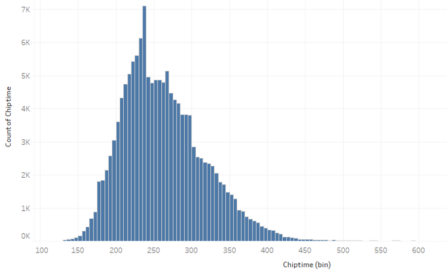

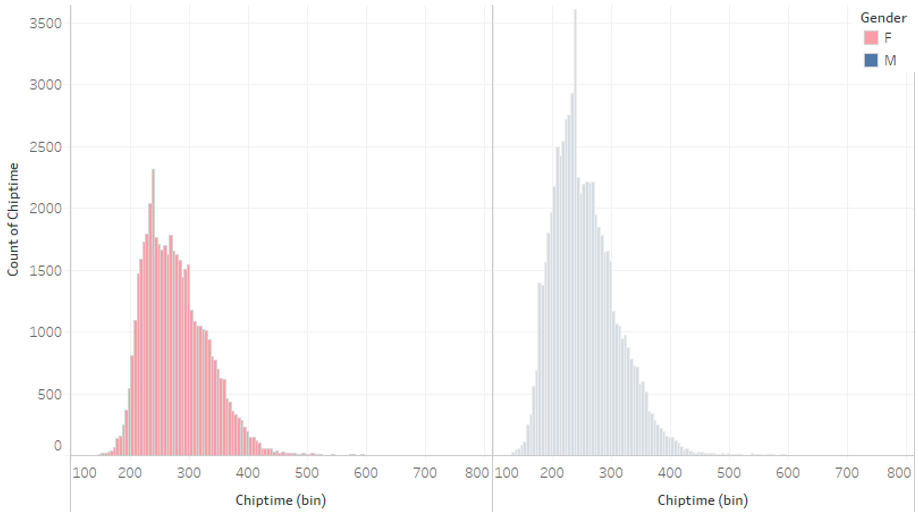

## Does Elevation Effect Finishing Time?

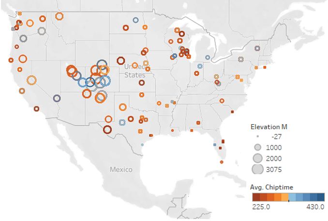

Utah and Colorado have a greater elevation than other states that host marathons. Map shows that the people in those states have a longer chip time (finish later) than those of lower elevation. You can learn that there is a connection to elevation and chip time, however there are always outliers. The greater the elevation the longer the takes.

## What Trends are seen when Months and Marathons are explored?

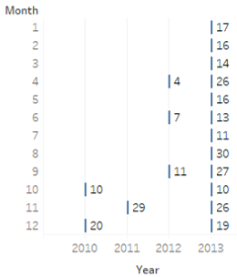

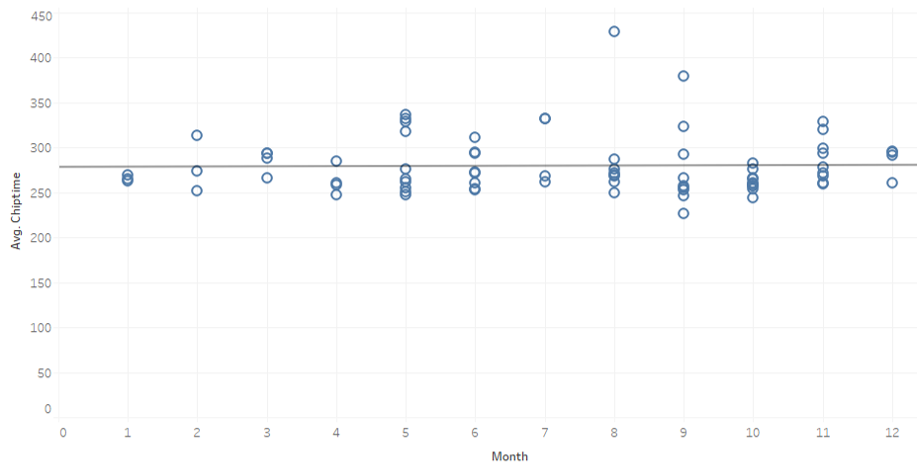

From this plot we can see what the date of marathons are. The data shows that races are every month in 2013 and are sporadic in other years. The trend between month and average finishing time is at about a constant 280 mins after the marathon starts

## Conclusion

Marathons are not just about speed and endurance. Marathon success is effected by elevation, temperature, weather, month, etc. This article illustrates how elevation and month effects the success of a race.

### H Tolli

“When data is explored I always come up with more questions. I would be fascinating to explore how weather effects chip time”

— Plots built in [Tableau](https://github.com/kctolli/CSE150/raw/master/tableau/CS3.twb)